# Introduction to R: Homework 3 - Key

### **Instructions**

Homework is optional, but we recommend it so you can get the most out of this course.

```r
## you can add more, or change...these are suggestions
library(tidyverse)
library(readr)
library(dplyr)
library(ggplot2)
library(tidyr)
```

### **Problem Set**

1. Bring the following dataset into R.

- The dataset is located at: https://daseh.org/data/Baltimore_surface_water_quality_data.csv.
- You can use the link, download it, or use whatever method you like for getting the file.
- Once you get the file, read the dataset in using `read_csv()` and assign it the name `water`.

```r
water <- read_csv("https://daseh.org/data/Baltimore_surface_water_quality_data.csv")
```

2. Check out and clean the columns of the `water` object.

- Run the `colnames()` function to take a look at the dataset column names.
- Rename the third column of `water` to “GPS_North” using the `rename()` function (tidyverse).
- Then rename the fourth column to “GPS_West”.
- Reassign the changed data to `water`.

```r
colnames(water)
```

```
## [1] "OBJECTID"             "Station"              "GPS Coordinate North"
## [4] "GPS Coordinate West"  "Parameter"            "Lab"
## [7] "Result"               "Unit"                 "datetime"
```

```r
water <- water |> rename(GPS_North = `GPS Coordinate North`)
water <- water |> rename(GPS_West = `GPS Coordinate West`)

# Alternatives
# water <- rename(water, GPS_North = "GPS Coordinate North", GPS_West = "GPS Coordinate West")
# Or pipe
# water <- water |> rename(GPS_North = "GPS Coordinate North", GPS_West = "GPS Coordinate West")
```

3. Clean up the “datetime” column.

- Convert the “datetime” column to POSIXct format using the `mdy_hm()` functions from the `lubridate` package. Call the new column “datetime_fixed”.
- Then create the variables “Month” and “Year” by extracting the month and year from the “datetime” column. (HINT: use `mutate()` and `year(datetime_fixed)` to create your new variables.)
- Reassign to `water`.

```r
#converting the date format to POSIXct
water <- water |> mutate(datetime_fixed = mdy_hm(datetime))

#creating new variables
water <- water |> mutate(Year = year(datetime_fixed))
water <- water |> mutate(Month = month(datetime_fixed))

# Alternative
# water <- water |> mutate( datetime_fixed = mdy_hm(datetime), Month = month(datetime_fixed), Year = year(datetime_fixed))
```

4. Separate “datetime_fixed” into two separate columns using the `separate()` function. Use `into = c("date", "time")` and `sep = " "` arguments. Replace the original `water` object by reassigning the new dataset to `water`.

```r
water <- water |> separate(`datetime_fixed`, into = c("date", "time"), sep = " ")
```

5. What is the class for “Result” column? Use `pull()`. Can you take the mean value? Why or why not?

```r
water |> pull(Result) |> class()
```

```
## [1] "character"
```

```r
# "Result" is of type "character". For some tests, the result is listed as below the detectable level, using a "<". R can only interpret this symbol as a character.
```

6. Some of the values of the “Result” column contain symbols “<”, “>”, and/or “=”. Replace these:

- Using `mutate()` and `str_remove()`.
- Repeat 3 times for patterns: `pattern = "<"` , `pattern = ">"`, then `pattern = "="`.
- Reassign the object to `water` each time.

```r
water <- water |> mutate(Result = str_remove(Result, pattern = "<"))
water <- water |> mutate(Result = str_remove(Result, pattern = ">"))
water <- water |> mutate(Result = str_remove(Result, pattern = "="))

# Alternative syntax
# water <- water |> mutate(
#   Result = str_remove(Result, pattern = "<"),
#   Result = str_remove(Result, pattern = ">"),
#   Result = str_remove(Result, pattern = "=")
# )
```

7. Use `mutate()` and `as.numeric()` to convert the “Result” column to numeric class. Then convert “Parameter” to a factor with `as.factor()`. Reassign to `water` both times.

```r
water <- water |>
  mutate(Result = as.numeric(Result))
water <- water |>
  mutate(Parameter = as.factor(Parameter))
```

8. How many different measurements (levels) are stored in the “Parameter” column? Use `pull()` and `levels()`.

```r
water |> pull(Parameter) |> levels()
```

```
##  [1] "Ammonia-Nitrogen"             "Antimony_Dissolved"
##  [3] "Antimony_Total"               "Arsenic_Dissolved"
##  [5] "Arsenic_Total"                "BOD5"
##  [7] "Cadmium_Dissolved"            "Cadmium_Total"
##  [9] "Chloride"                     "chlorine"
## [11] "Chlorine"                     "Chlorine_Spec"
## [13] "Chromium_Dissolved"           "Chromium_Total"
## [15] "COD"                          "Conductivity"
## [17] "Copper_Dissolved"             "Copper_Total"
## [19] "Copper, Total"                "Dissolved Oxygen"
## [21] "E. Coli"                      "Enterococcus"
## [23] "Fecal Coliform"               "Fluoride"
## [25] "Hach Ammonia-Nitrogen"        "Hardness"
## [27] "Iron, Total"                  "Lead_Dissolved"
## [29] "Lead_Total"                   "Lead, Total"
## [31] "Maximum Depth"                "Nitrate+Nitrite-Nitrogen"
## [33] "Oil & Grease"                 "Ortho-Phosphate"
## [35] "pH"                           "Secchi Disk"
## [37] "SGT-HEM"                      "Sodium"
## [39] "Suspended Solids"             "TKN"
## [41] "Total Coliform"               "Total Petroleum Hydrocarbons"
## [43] "Total Phenolics"              "Total Phosphorus"
## [45] "Turbidity"                    "Water Temperature"
## [47] "Zinc_Dissolved"               "Zinc_Total"
## [49] "Zinc, Total"
```

```r
#There are 49 different types of measurements in this dataset.
```

9. Use the `pct_complete()` function in the `naniar` package to determine the percent missing data in “Results”. You might need to load and install `naniar`!

```r
library(naniar)
pct_complete(water)
```

```
## [1] 99.99922
```

10. Are there any parameter levels that have an incomplete record in `water` across all years?

- Create a new dataframe called `na_counts`.
- Use `group_by()` on “Parameter”
- Use `summarize()` on Result checking for NA values with `sum(is.na(Result))`.
- Use `filter()` to keep only rows with > 0 NA values.

```r
na_counts <- water |>
  group_by(Parameter) |>
  summarize(na_count = sum(is.na(Result)))

na_counts |> filter(na_count > 0)
```

```
## # A tibble: 3 × 2
##   Parameter na_count
##   <fct>        <int>
## 1 E. Coli         27
## 2 Hardness        11
## 3 Turbidity        3
```

11. Subset `water` so that it only contains results for the years 2010 - 2024, using `&` and the `filter()` function. Make sure to include both the years 2010 and 2024. Confirm your filtering worked by looking at the `range()` of “Year”. Assign this subsetted tibble to `water_subset`.

```r
water_subset <- water |> filter(Year >= 2010 & Year <= 2024)
water_subset |>
  pull(Year) |>
  range() # confirm it worked
```

```
## [1] 2010 2024
```

12. Subset `water_subset` so that the “Parameter” column only contains results from the tests for “Dissolved Oxygen”, “pH”, and “Water Temperature”. Use the `%in%` operator and the `filter()` function. Make sure to reassign to `water_subset`.

```r
water_subset <- water_subset |>
  filter(Parameter %in% c("Dissolved Oxygen", "pH", "Water Temperature"))
```

13. Load the new dataset “Baltimore_rainfall_HamiltonAve.csv” into R.

- The dataset is located at: https://daseh.org/data/Baltimore_rainfall_HamiltonAve.csv.
- You can use the link, download it, or use whatever method you like for getting the file.
- Once you get the file, read the dataset in using `read_csv()` and assign it the name `rainfall`.

This dataset contains measured precipitation by month, as collected near the Hamilton Ave testing location in Baltimore.

```r
rainfall <- read_csv("https://daseh.org/data/Baltimore_rainfall_HamiltonAve.csv")
```

14. Reshape `rainfall` into long format using `pivot_longer()`. The reshaped dataset should contain three columns: year (“Year”), month (“Month”), and amount of rainfall (“Precip”).

- Pivot all columns except “Month”. **Hint:** listing `!COLUMN` or `-COLUMN` means everything except COLUMN.
- Make sure `names_to` is “Year” and `values_to` is “Precip”.
- Assign the reshaped dataset to `rainfall_long`.

```r
rainfall_long <- rainfall |> pivot_longer(!Month, names_to = "Year", values_to = "Precip")
```

15. How many possible “Year” and “Month” combinations are in `rainfall_long`? Use `count()`. How does this compare to `nrow()`? Can you use this information to determine the number of observations per each Year and Month combination?

```r
rainfall_long |> count(Year, Month)
```

```
## # A tibble: 208 × 3
##    Year  Month      n
##    <chr> <chr>  <int>
##  1 2009  Annual     1
##  2 2009  Apr        1
##  3 2009  Aug        1
##  4 2009  Dec        1
##  5 2009  Feb        1
##  6 2009  Jan        1
##  7 2009  Jul        1
##  8 2009  Jun        1
##  9 2009  Mar        1
## 10 2009  May        1
## # ℹ 198 more rows
```

```r
nrow(rainfall_long)
```

```
## [1] 208
```

```r
# They are the same; the dataset contains one observation per Year and Month combination.
```

16. We would like to join the rainfall measurements dataset with the Baltimore surface water quality dataset, but we need to do a bit more wrangling first. Because the rainfall measures were collected near the Hamilton Ave water testing site, let’s keep only the Hamilton Ave data from the `water_subset` data, using `filter()`. Assign this to `water_Ham`.

- The “Station” column should be “HAMILTON AVE.”

```r
water_Ham <- water_subset |> filter(Station == "HAMILTON AVE.")
```

17. Right-join `water_Ham` and `rainfall_long` by “Month” and “Year” using `right_join()`. Assign the joined dataset to the name `water_rain`. Did this join attempt work? Why or why not?

```r
water_rain <- water_Ham |> right_join(rainfall_long, by = c("Month", "Year"))
```

```
## Error in `right_join()`:
## ! Can't join `x$Month` with `y$Month` due to incompatible types.
## ℹ `x$Month` is a <double>.
## ℹ `y$Month` is a <character>.
```

```r
#This attempted join did not work, because the class of Month is not the same between the two datasets!
```

18. Check the class of the “Month” column in each dataset. Reformat “Month” in `rainfall_long` so that it matches the format in `water_Ham`. Use `case_when()` and `mutate()`, then reassign to `rainfall_long`.

```r
rainfall_long <- rainfall_long |>
  mutate(Month = case_when(
    Month == "Jan" ~ 1,
    Month == "Feb" ~ 2,
    Month == "Mar" ~ 3,
    Month == "Apr" ~ 4,
    Month == "May" ~ 5,
    Month == "Jun" ~ 6,
    Month == "Jul" ~ 7,
    Month == "Aug" ~ 8,
    Month == "Sep" ~ 9,
    Month == "Oct" ~ 10,
    Month == "Nov" ~ 11,
    Month == "Dec" ~ 12
    ))
```

19. NOW try to right-join `water_Ham` and `rainfall_long` by “Month” and “Year” and assign the joined dataset to the name `water_rain`. Did this join attempt work?

```r
water_rain <- water_Ham |> right_join(rainfall_long, by = c("Month", "Year"))
```

```
## Error in `right_join()`:
## ! Can't join `x$Year` with `y$Year` due to incompatible types.
## ℹ `x$Year` is a <double>.
## ℹ `y$Year` is a <character>.
```

```r
#This attempted join did not work either, because "Year" is a different format between both datasets too!
```

20. Fix the differences between the classes of “Year” by changing `rainfall_long`. Then right-join the two datasets to make “water_rain”.

```r
rainfall_long <- rainfall_long |>
  mutate(Year = as.double(Year))

water_rain <- water_Ham |> right_join(rainfall_long, by = c("Month", "Year"))
```

21. Subset `water_rain` so that “Parameter” is “pH”. Plot points with “Precip” on the x axis, “Result” on the y axis, and “Year” as color. Facet the plot by Month. You can use esquisse or ggplot (whichever you prefer).

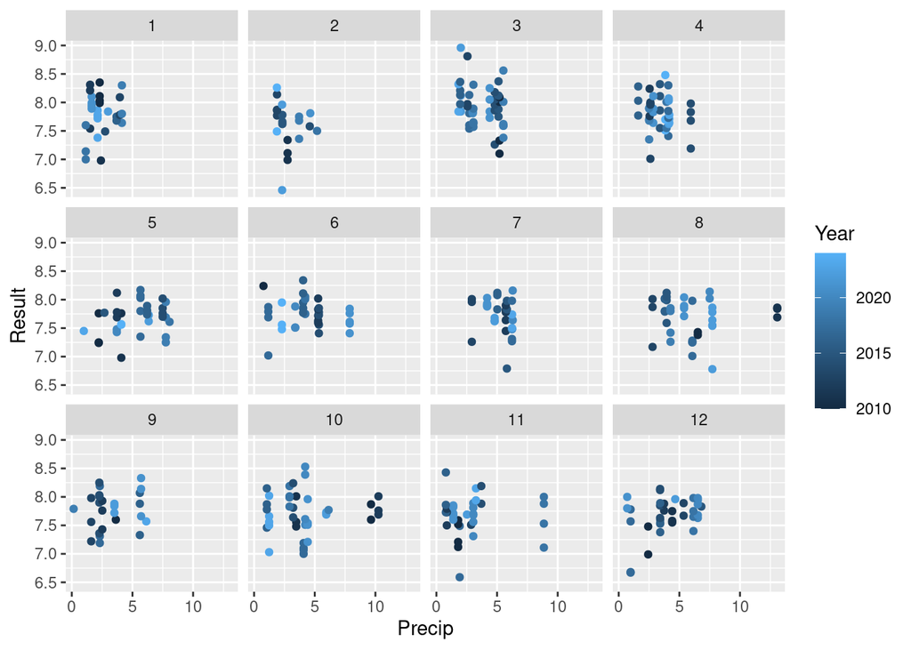

```r
plot_subset <- water_rain |> filter(Parameter == "pH")

#If using esquisse:
#library(esquisse)
#esquisser(plot_subset)

#If using ggplot:
ggplot(data = plot_subset, aes(x = Precip, y = Result, color = Year)) +
  geom_point() +
  facet_wrap(~Month)
```

```r
# Alternative syntax
# water_rain |>
#   filter(Parameter == "pH") |>
#   ggplot(aes(x = Precip, y = Result, color = Year)) +
#   geom_point() +
#   facet_wrap(~ Month)
```

22. Create a new plot changing the measurement units. This time, subset `water_rain` so that “Parameter” is “Water Temperature”. Plot points with “Precip” on the x axis, “Result” on the y axis, and “Year” as color. Facet the plot by Month. You can use esquisse or ggplot (whichever you prefer). Do the temperatures follow the expected seasonal climate across months (highs and lows)?

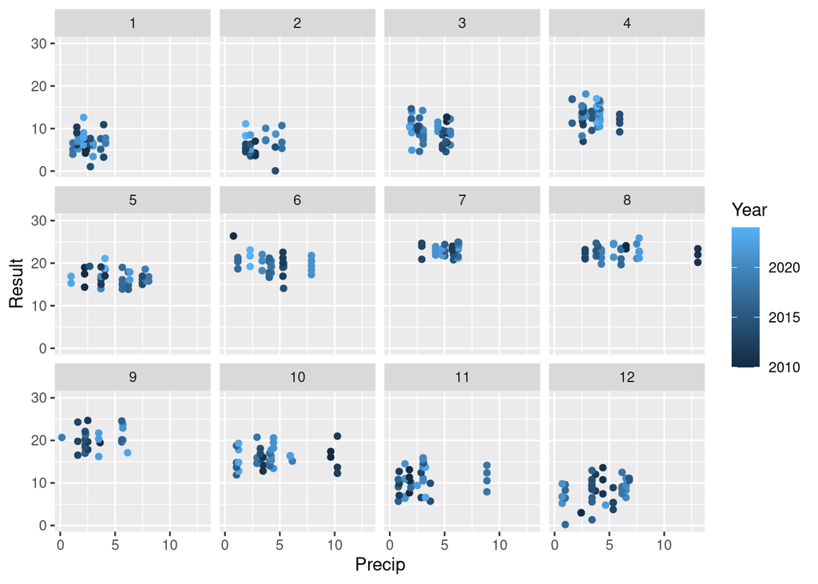

```r
plot_subset <- water_rain |> filter(Parameter == "Water Temperature")

#If using esquisse:
#library(esquisse)
#esquisser(plot_subset)

#If using ggplot:
ggplot(data = plot_subset, aes(x = Precip, y = Result, color = Year)) +
  geom_point() +
  facet_wrap(~Month)
```

```r
# Yes, temperatures are higher in summer and lower in winter months.
```